# Exam 3

Izzi Grasso Due: 5/2/2020

```r
library(tidyverse)
library(ggplot2)
```

## Problem 1

#### Data

```r
df1 <- data.frame(
  Depletion = c(85, 55, 40, 77),
  ModifiedHess = c(75, 45, 35, 67),
  Surber = c(31, 20, 9, 37),
  SubstrateRemoval = c(43, 21, 15, 27),
  Kicknet = c(17, 10, 8, 15)
)
df2 <- df1 %>%
  summarise_each(funs(mean)) %>%
  gather(Var, Val)
```

```
`summarise_each()` is deprecated.
Use `summarise_all()`, `summarise_at()` or `summarise_if()` instead.
To map `funs` over all variables, use `summarise_all()`
```

#### a. Plot

```r
df2 <- df1 %>%
  summarise_each(funs(mean)) %>%
  gather(Var, Val)
```

```
`summarise_each()` is deprecated.
Use `summarise_all()`, `summarise_at()` or `summarise_if()` instead.
To map `funs` over all variables, use `summarise_all()`
```

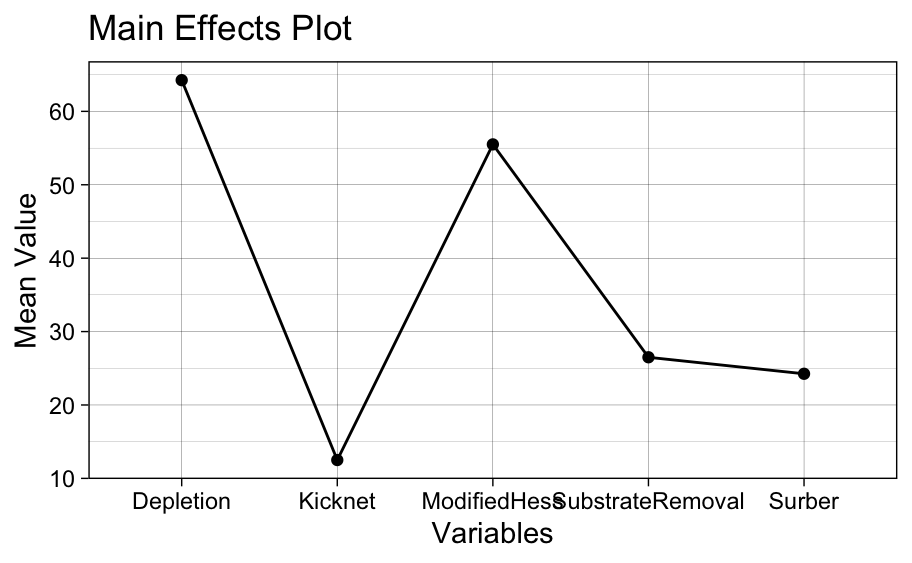

```r
ggplot(df2, aes(x = as.factor(Var), y = Val)) +
  geom_line(aes(group = 1)) +
  geom_point() +
  theme_linedraw() +
  labs( title = "Main Effects Plot",
        x = "Variables",
        y = "Mean Value")
```

```r
NA
```

Interpretation: Since the line is not at all flat, I would expect to reject the null hypothesis. Kicknet seems to be much lower than Modified Hess and Depletion.

#### b.

Null Hypothesis: The distributions are the same location Alternative Hyp: Not null.

```r
df1 <- df1 %>%
  gather(Var, Val)
kruskal.test(Val ~ as.factor(Var), data = df1)
```

```
    Kruskal-Wallis rank sum test

data:  Val by as.factor(Var)
Kruskal-Wallis chi-squared = 13.986, df = 4, p-value =
0.007341
```

At $\alpha$ = 0.05 we reject the null hypothesis. There is significant evidence that the sampling procedures yield different species counts.

#### c.

```r
pairwise.wilcox.test(df1$Val, df1$Var, p.adjust.method = "bonferroni")
```

```
cannot compute exact p-value with ties
```

```
    Pairwise comparisons using Wilcoxon rank sum test

data:  df1$Val and df1$Var

                 Depletion Kicknet ModifiedHess
Kicknet          0.29      -       -
ModifiedHess     1.00      0.29    -
SubstrateRemoval 0.57      0.81    0.57
Surber           0.29      1.00    0.57
                 SubstrateRemoval
Kicknet          -
ModifiedHess     -
SubstrateRemoval -
Surber           1.00

P value adjustment method: bonferroni
```

At $\alpha$ = 0.05, we fail to reject the null hypothesis.

## Problem 2

#### Data

```r
TarContent <- c(14, 17, 28, 17, 16, 13, 24, 25, 18, 31)
NicotineContent <- c(0.9, 1.1, 1.6, 1.3, 1.0, 0.8, 1.5, 1.4, 1.2, 2.0)
```

#### a & b

Null hypothesis: $\rho$ = 0 Alternative hyp: $\rho$ $\neq$ 0

```r
cor.test(TarContent, NicotineContent, method = "spearman")
```

```
Cannot compute exact p-value with ties
```

```
    Spearman's rank correlation rho

data:  TarContent and NicotineContent
S = 5.516, p-value = 5.248e-06
alternative hypothesis: true rho is not equal to 0
sample estimates:
      rho
0.9665698
```

At $\alpha$ = 0.05 we reject the null hypothesis. There is a linear correlation between the amount of tar and the amount of nicotine found in cigarettes.

## Problem 3

#### Data

```r
x = 261
n = 302
y = 401
m = 454
p_A = x/n
p_B = y/m
```

#### a.

```r
z_ = qnorm(0.005, mean = 0, sd = 1, lower.tail = FALSE)
LCI = (p_A - p_B) - z_*sqrt(x*(n-x)/(n^3)+y*(m-y)/(m^3))
UCI = (p_A - p_B) + z_*sqrt(x*(n-x)/(n^3)+y*(m-y)/(m^3))
LCI
```

```
[1] -0.08293269
```

```r
UCI
```

```
[1] 0.04488969
```

#### b.

```r
z_ = qnorm(0.05, mean = 0, sd = 1, lower.tail = FALSE)
LCI = (p_A - p_B) - z_*sqrt(x*(n-x)/(n^3)+y*(m-y)/(m^3))
UCI = (p_A - p_B) + z_*sqrt(x*(n-x)/(n^3)+y*(m-y)/(m^3))
LCI
```

```
[1] -0.05983343
```

```r
UCI
```

```
[1] 0.02179042
```

#### c.

```r
z_ = qnorm(0.025, mean = 0, sd = 1, lower.tail = FALSE)
LCI = (x/n - y/m) - z_*sqrt(x*(n-x)/(n^3)+y*(m-y)/(m^3))
UCI = (x/n - y/m) + z_*sqrt(x*(n-x)/(n^3)+y*(m-y)/(m^3))
LCI
```

```
[1] -0.06765191
```

```r
UCI
```

```
[1] 0.02960891
```

#### d.

Null Hypothesis: $p_A$ = $p_B$ Alternative Hyp: $p_A$ $\neq$ $p_B$

```r
p_hat = (x+y)/(n+m)
z_star = (p_A-p_B)/sqrt(p_hat*(1-p_hat)*(1/n+1/m))
2*pnorm(z_star, mean = 0, sd = 1)
```

```
[1] 0.4375565
```

At $\alpha$ = 0.05 we fail to reject the null hypothesis.

## Problem 4

Null Hypothesis: $s^2$ $\leq$ $\sigma^2$ Alternative hyp: $s^2$ > $\sigma^2$

```r
SSquared = 0.0002
SigmaSquared = 0.0003
alpha = 0.05
n = 10
TestStatistic <- ((n-1)*SSquared)/SigmaSquared
ChiSq <- qchisq((1-alpha), df = (n-1))
TestStatistic > ChiSq
```

```
[1] FALSE
```

## Problem 5

#### Data

```r
df3 <- data.frame(
  Value = c(12.8, 11.7, 11.5, 12.6,
            10.6, 14.2, 14.7, 16.5,
            11.7, 11.8, 13.6, 15.4,
            10.7, 9.9, 10.7, 9.6,
            11.0, 13.8, 15.9, 17.1),
  Treatment = rep(1:4, times = 5),
  Block = rep(1:5, times = 1, each = 4)
)
```

#### Friedman Test, RBD

Null hypothesis: Distributions are identical Alternative hypothesis: Not null hypothesis.

```r
friedman.test(df3$Value, df3$Treatment, df3$Block)
```

```
    Friedman rank sum test

data:  df3$Value, df3$Treatment and df3$Block
Friedman chi-squared = 2.8776, df = 3, p-value =
0.4109
```

At $\alpha$ = 0.05, we fail to reject the null hypothesis. There is not significant evidence to show that there is a difference between treatment means.